# Fan Shi

References: http://stackoverflow.com/questions/21716567/use-ggpairs-to-create-this-plot

> **Tip**: You will see quoted sections like this throughout the template to help you construct your report. Make sure that you remove these notes before you finish and submit your project!

> **Tip**: One of the requirements of this project is that your code follows good formatting techniques, including limiting your lines to 80 characters or less. If you're using RStudio, go into Preferences > Code > Display to set up a margin line to help you keep track of this guideline!

> Introduction to the data in this study This tidy data set contains 1,599 red wines with 11 variables on the chemical properties of the wine. At least 3 wine experts rated the quality of each wine, providing a rating between 0 (very bad) and 10 (very excellent).

# Univariate Plots Section

> **Tip**: In this section, you should perform some preliminary exploration of your dataset. Run some summaries of the data and create univariate plots to understand the structure of the individual variables in your dataset. Don't forget to add a comment after each plot or closely-related group of plots! There should be multiple code chunks and text sections; the first one below is just to help you get started. 1. Overview of the Red Wine Data Set

```
##   X fixed.acidity volatile.acidity citric.acid residual.sugar chlorides
## 1 1           7.4             0.70        0.00            1.9     0.076
## 2 2           7.8             0.88        0.00            2.6     0.098
## 3 3           7.8             0.76        0.04            2.3     0.092
## 4 4          11.2             0.28        0.56            1.9     0.075
## 5 5           7.4             0.70        0.00            1.9     0.076
## 6 6           7.4             0.66        0.00            1.8     0.075
##   free.sulfur.dioxide total.sulfur.dioxide density   pH sulphates alcohol
## 1                  11                   34  0.9978 3.51      0.56     9.4
## 2                  25                   67  0.9968 3.20      0.68     9.8
## 3                  15                   54  0.9970 3.26      0.65     9.8
## 4                  17                   60  0.9980 3.16      0.58     9.8
## 5                  11                   34  0.9978 3.51      0.56     9.4
## 6                  13                   40  0.9978 3.51      0.56     9.4
##   quality
## 1       5
## 2       5
## 3       5
## 4       6
## 5       5
## 6       5
```

```
##         X fixed.acidity volatile.acidity citric.acid residual.sugar
## 1594 1594           6.8            0.620        0.08            1.9
## 1595 1595           6.2            0.600        0.08            2.0
## 1596 1596           5.9            0.550        0.10            2.2
## 1597 1597           6.3            0.510        0.13            2.3
## 1598 1598           5.9            0.645        0.12            2.0
## 1599 1599           6.0            0.310        0.47            3.6
##      chlorides free.sulfur.dioxide total.sulfur.dioxide density   pH
## 1594     0.068                  28                   38 0.99651 3.42
## 1595     0.090                  32                   44 0.99490 3.45
## 1596     0.062                  39                   51 0.99512 3.52
## 1597     0.076                  29                   40 0.99574 3.42
## 1598     0.075                  32                   44 0.99547 3.57
## 1599     0.067                  18                   42 0.99549 3.39
##      sulphates alcohol quality
## 1594      0.82     9.5       6
## 1595      0.58    10.5       5
## 1596      0.76    11.2       6
## 1597      0.75    11.0       6
## 1598      0.71    10.2       5
## 1599      0.66    11.0       6
```

```
##  [1] "X"                    "fixed.acidity"        "volatile.acidity"
##  [4] "citric.acid"          "residual.sugar"       "chlorides"
##  [7] "free.sulfur.dioxide"  "total.sulfur.dioxide" "density"
## [10] "pH"                   "sulphates"            "alcohol"
## [13] "quality"
```

The result gives us the first 6 and last 6 rows of the red wine data table. It seems that we have 11 attributes, which all together, contribute to the final quality of the wine. Also, the total number of the tested wines are 1599 bottles.

At this time, I am very curious to know the general statistical information of each attribute:

```
##        X          fixed.acidity   volatile.acidity  citric.acid
##  Min.   :   1.0   Min.   : 4.60   Min.   :0.1200   Min.   :0.000
##  1st Qu.: 400.5   1st Qu.: 7.10   1st Qu.:0.3900   1st Qu.:0.090
##  Median : 800.0   Median : 7.90   Median :0.5200   Median :0.260
##  Mean   : 800.0   Mean   : 8.32   Mean   :0.5278   Mean   :0.271
##  3rd Qu.:1199.5   3rd Qu.: 9.20   3rd Qu.:0.6400   3rd Qu.:0.420
##  Max.   :1599.0   Max.   :15.90   Max.   :1.5800   Max.   :1.000
##  residual.sugar     chlorides       free.sulfur.dioxide
##  Min.   : 0.900   Min.   :0.01200   Min.   : 1.00
##  1st Qu.: 1.900   1st Qu.:0.07000   1st Qu.: 7.00
##  Median : 2.200   Median :0.07900   Median :14.00
##  Mean   : 2.539   Mean   :0.08747   Mean   :15.87
##  3rd Qu.: 2.600   3rd Qu.:0.09000   3rd Qu.:21.00
##  Max.   :15.500   Max.   :0.61100   Max.   :72.00
##  total.sulfur.dioxide    density             pH          sulphates
##  Min.   :  6.00       Min.   :0.9901   Min.   :2.740   Min.   :0.3300
##  1st Qu.: 22.00       1st Qu.:0.9956   1st Qu.:3.210   1st Qu.:0.5500
##  Median : 38.00       Median :0.9968   Median :3.310   Median :0.6200
##  Mean   : 46.47       Mean   :0.9967   Mean   :3.311   Mean   :0.6581
##  3rd Qu.: 62.00       3rd Qu.:0.9978   3rd Qu.:3.400   3rd Qu.:0.7300
##  Max.   :289.00       Max.   :1.0037   Max.   :4.010   Max.   :2.0000
##     alcohol         quality
##  Min.   : 8.40   Min.   :3.000
##  1st Qu.: 9.50   1st Qu.:5.000
##  Median :10.20   Median :6.000
##  Mean   :10.42   Mean   :5.636
##  3rd Qu.:11.10   3rd Qu.:6.000
##  Max.   :14.90   Max.   :8.000
```

Clearly, we have some attributes, featuring the abolute value, such as volatile acidity and free.sulfur.dioxide, and some attribute featuring the relative value, such as citric acid. To further look at each future, we need to understand the property of each attribute:

```
## 'data.frame':    1599 obs. of  13 variables:
##  $ X                   : int  1 2 3 4 5 6 7 8 9 10 ...
##  $ fixed.acidity       : num  7.4 7.8 7.8 11.2 7.4 7.4 7.9 7.3 7.8 7.5 ...
##  $ volatile.acidity    : num  0.7 0.88 0.76 0.28 0.7 0.66 0.6 0.65 0.58 0.5 ...
##  $ citric.acid         : num  0 0 0.04 0.56 0 0 0.06 0 0.02 0.36 ...
##  $ residual.sugar      : num  1.9 2.6 2.3 1.9 1.9 1.8 1.6 1.2 2 6.1 ...
##  $ chlorides           : num  0.076 0.098 0.092 0.075 0.076 0.075 0.069 0.065 0.073 0.071 ...
##  $ free.sulfur.dioxide : num  11 25 15 17 11 13 15 15 9 17 ...
##  $ total.sulfur.dioxide: num  34 67 54 60 34 40 59 21 18 102 ...
##  $ density             : num  0.998 0.997 0.997 0.998 0.998 ...
##  $ pH                  : num  3.51 3.2 3.26 3.16 3.51 3.51 3.3 3.39 3.36 3.35 ...
##  $ sulphates           : num  0.56 0.68 0.65 0.58 0.56 0.56 0.46 0.47 0.57 0.8 ...
##  $ alcohol             : num  9.4 9.8 9.8 9.8 9.4 9.4 9.4 10 9.5 10.5 ...
##  $ quality             : int  5 5 5 6 5 5 5 7 7 5 ...
```

It looks like all the attributes are float numbers, excpet the quality. Next, we will try to plot each attribute.

1. Unvariable plots 2.1 Wine quality As quality is the most important attribute we care about, I would like do some exploration on it first.

```
##    Min. 1st Qu.  Median    Mean 3rd Qu.    Max.
##   3.000   5.000   6.000   5.636   6.000   8.000
```

Just like the summary section about the quality, obtained previously, we have the actual quality range of all the red wines in the test， [3, 8], which is smaller than the total range of the red wine quality scoring, [0, 10]. With such statistical values, we have a general idea about the quality of these red wine. However, we still lack of the detailed distribution of quality of the red wine, as multi distribution may show the similar statistical values, but variate on what portion of good bottles are there. To plot the distribution within quality, we will have to count the number of bottles in each quality score:

```
##
##   3   4   5   6   7   8
##  10  53 681 638 199  18
```

Then, we can plot it:

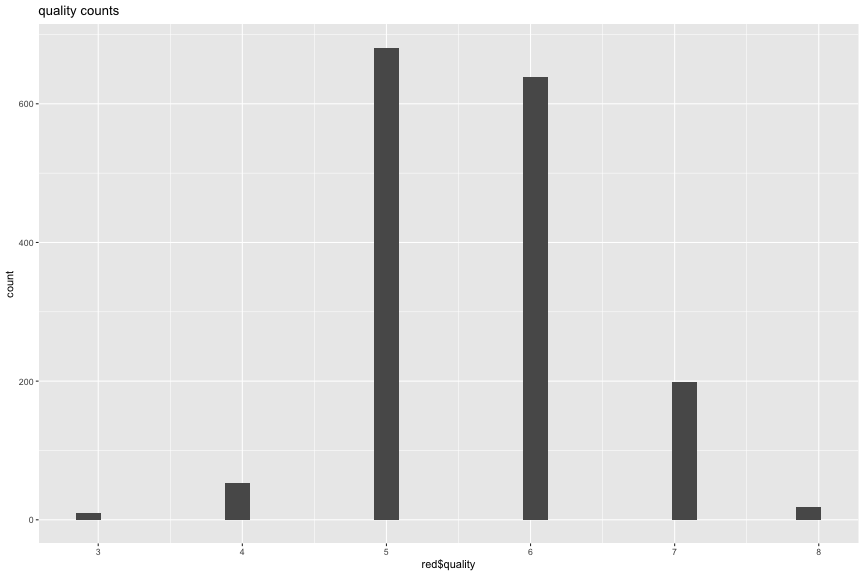

The distribution of the quality is close to normal distribution.

Based on my own opinion on the factors affecting the quality wine, here I will select the density, alcohol level, volatile acidity, and chloride level, for initial investigation. 2.2 Density of wine

```
##    Min. 1st Qu.  Median    Mean 3rd Qu.    Max.
##  0.9901  0.9956  0.9968  0.9967  0.9978  1.0040
```

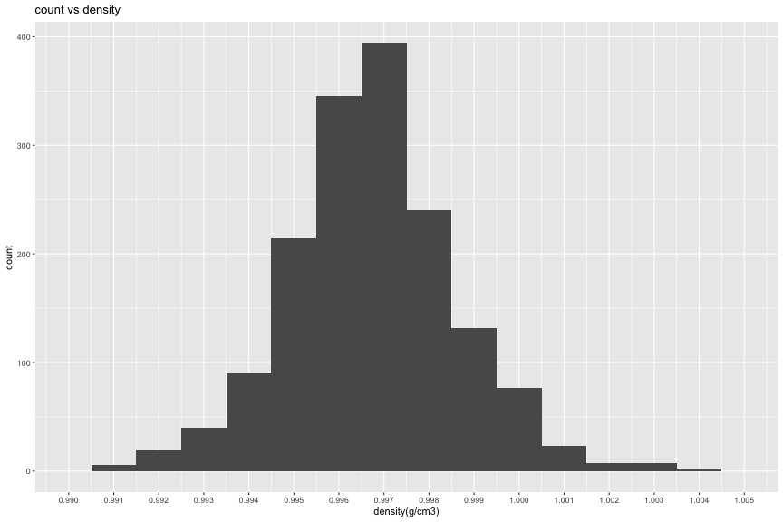

The density of the red wine obeys the normal distribution generally speaking.

2.3 Alcohol level

```
##    Min. 1st Qu.  Median    Mean 3rd Qu.    Max.
##    8.40    9.50   10.20   10.42   11.10   14.90
```

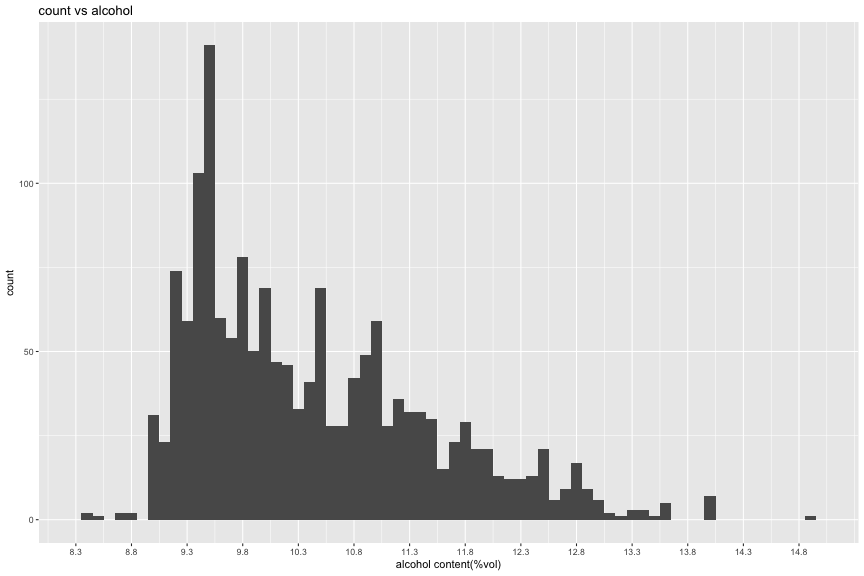

The distribution of alcohol level seems to obey skewed distribution, with several outliers on both ends.

2.4 Volatile acidity

```
##    Min. 1st Qu.  Median    Mean 3rd Qu.    Max.
##  0.1200  0.3900  0.5200  0.5278  0.6400  1.5800
```

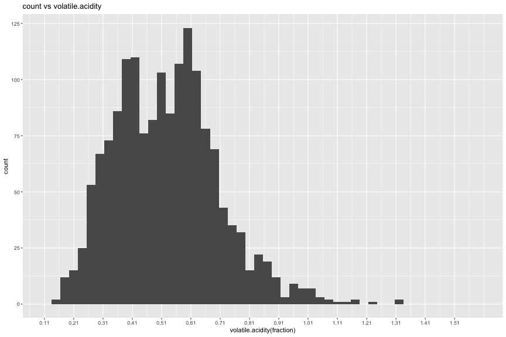

Obviously, the volatile acidity is close to the bimodal distribution in the general trend. I will say that there are several outliers on the right tail side of the plot.

2.5 Chloride level

```
##    Min. 1st Qu.  Median    Mean 3rd Qu.    Max.
## 0.01200 0.07000 0.07900 0.08747 0.09000 0.61100
```

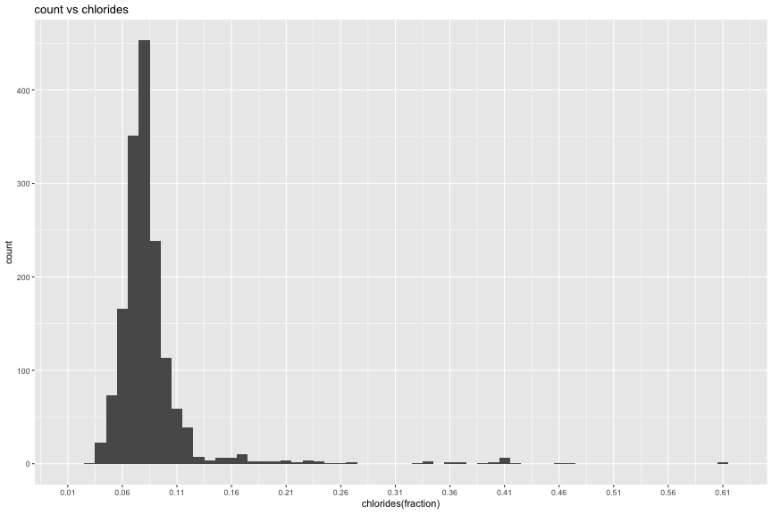

```
##    Min. 1st Qu.  Median    Mean 3rd Qu.    Max.
##    4.60    7.10    7.90    8.32    9.20   15.90
```

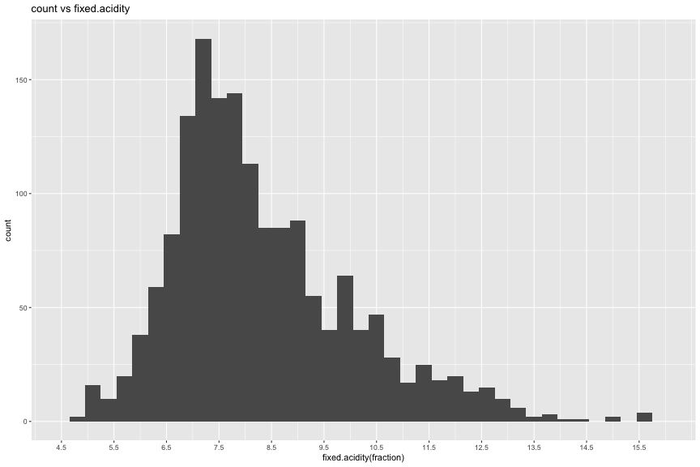

Now we can notice that the distribution of fixed.acidity is skewed around 7.7.

```
##    Min. 1st Qu.  Median    Mean 3rd Qu.    Max.
##   0.900   1.900   2.200   2.539   2.600  15.500
```

[figure not shown]

```
##    Min. 1st Qu.  Median    Mean 3rd Qu.    Max.
##  0.3300  0.5500  0.6200  0.6581  0.7300  2.0000
```

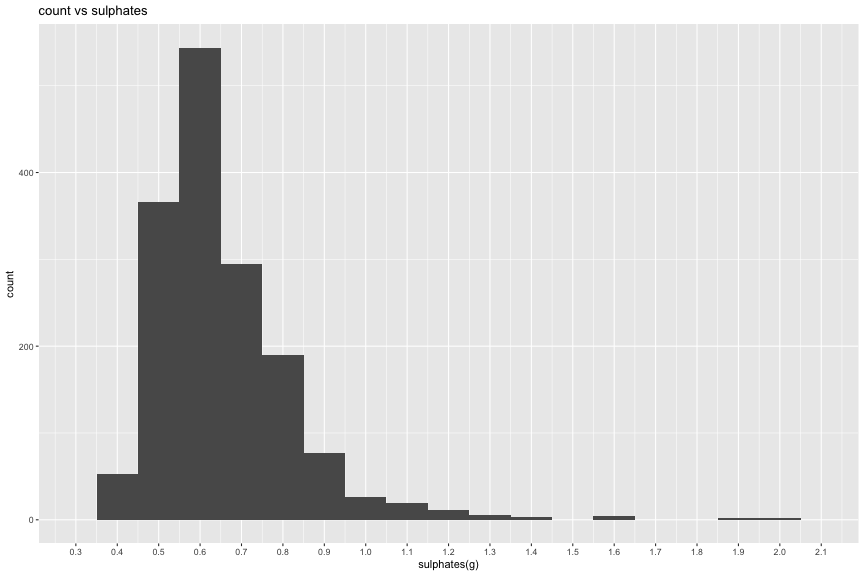

The distribution of sulphates shows the most counts around 0.6 g. The largest sulphate values appears at 2.0.

```
##    Min. 1st Qu.  Median    Mean 3rd Qu.    Max.
##    6.00   22.00   38.00   46.47   62.00  289.00
```

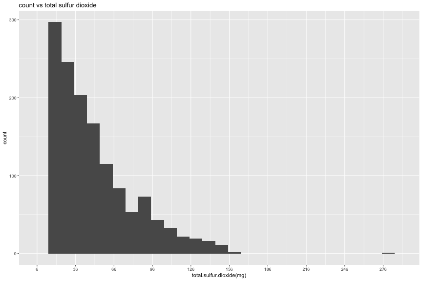

We can notice that total.suful.dioxide distribution is half of the normal distribution starting from 6.

```
##    Min. 1st Qu.  Median    Mean 3rd Qu.    Max.
##    1.00    7.00   14.00   15.87   21.00   72.00
```

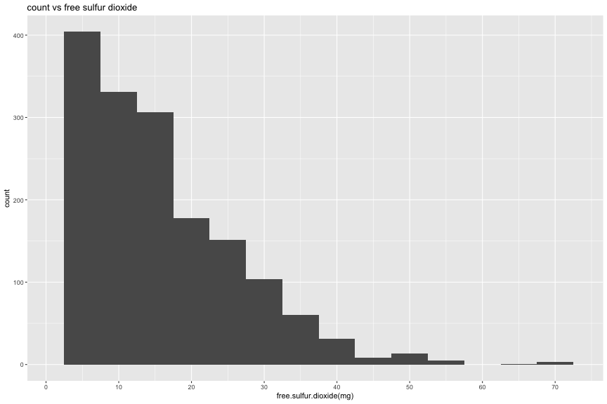

Similar to the total sulfur dioxide, the free sulfur dioxide also obeys the half normal distribution, but starting from 1 mg.

```
##    Min. 1st Qu.  Median    Mean 3rd Qu.    Max.
##   2.740   3.210   3.310   3.311   3.400   4.010
```

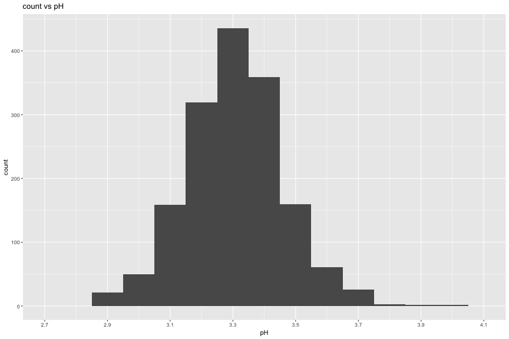

The pH distribution closely obeys the normal distribution, centering around 3.3.

> **Tip**: Make sure that you leave a blank line between the start / end of each code block and the end / start of your Markdown text so that it is formatted nicely in the knitted text. Note as well that text on consecutive lines is treated as a single space. Make sure you have a blank line between your paragraphs so that they too are formatted for easy readability.

# Univariate Analysis

> **Tip**: Now that you've completed your univariate explorations, it's time to reflect on and summarize what you've found. Use the questions below to help you gather your observations and add your own if you have other thoughts!

### What is the structure of your dataset?

This dataset contains 1599 observations and 13 variables. I will take quality as the dependent varaible and the other variables as the independent variables.

### What is/are the main feature(s) of interest in your dataset?

The main feature is the quality of interest in my datast.

### What other features in the dataset do you think will help support your \

investigation into your feature(s) of interest? $ volatile.acidity  
$ citric.acid  
$ residual.sugar  
$ chlorides  
$ free.sulfur.dioxide $ total.sulfur.dioxide $ density  
$ pH  
$ sulphates  
$ alcohol  
$ quality :

### Did you create any new variables from existing variables in the dataset?

No, I did not.

### Of the features you investigated, were there any unusual distributions? \

Did you perform any operations on the data to tidy, adjust, or change the form \ of the data? If so, why did you do this? No, I did not. The dataset is already in a good condition.

# Bivariate Plots Section

> **Tip**: Based on what you saw in the univariate plots, what relationships between variables might be interesting to look at in this section? Don't limit yourself to relationships between a main output feature and one of the supporting variables. Try to look at relationships between supporting variables as well.

# Bivariate Analysis

> **Tip**: As before, summarize what you found in your bivariate explorations here. Use the questions below to guide your discussion.

To find out the pairs of the attributes that I would like to deeply look into, I would like to find out the correlation of each in the red wine data set first.

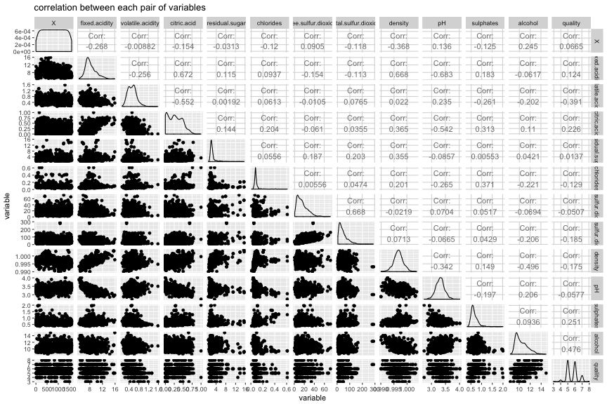

### Talk about some of the relationships you observed in this part of the \

investigation. How did the feature(s) of interest vary with other features in \ the dataset? The quality of the red wine are mainly effected by the volatile.acidity and alcohol content.

3.1 density vs alcohol As alcohol is smaller than water in densitry, we can expect a minus slope line fitted bween those to attributes.

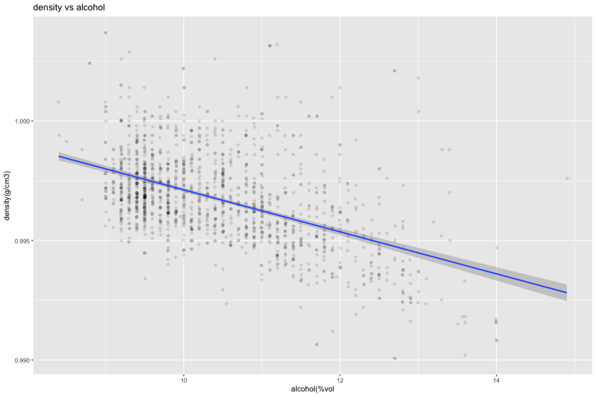

Our expectation is verified. 3. 2 fixed acidity v.s. density The density and fixed acidity of the red wine may have a positive slope for their fitted line, as acidity may induce a stronger H bond, and thus enhance the density.

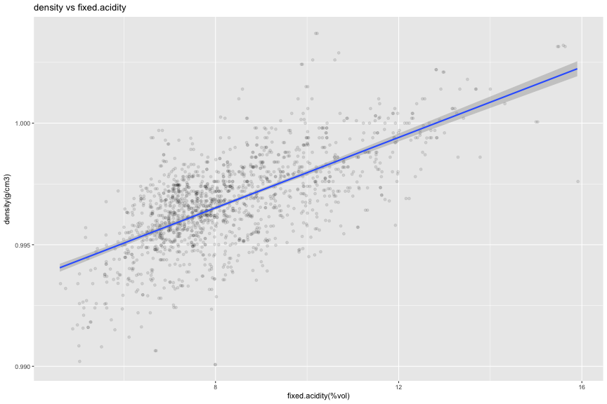

As expcted.

3.3 The residual sugar v.s. density Sugar has larger density than water. Thus, it is reasonble that more dissolved sugar could enhance the density of wine, which is verified by the following plot.

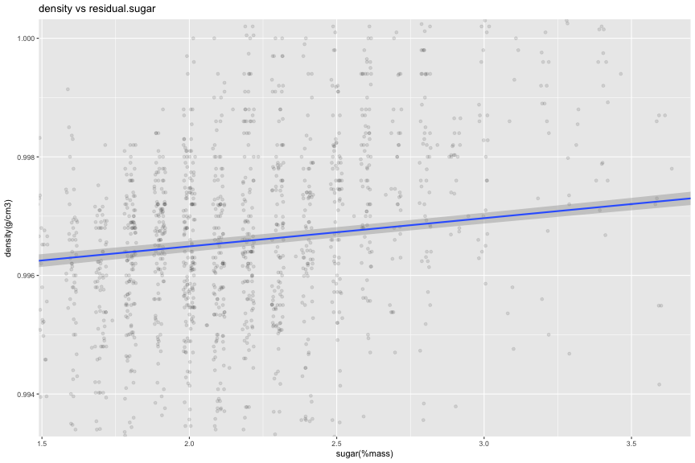

3.4 Chlorides v.s. density Similarly, the chloride chemicals disolved in wine is also heavier than water, so as to enhance the total density of the wine. This guess is verified by the following plot.

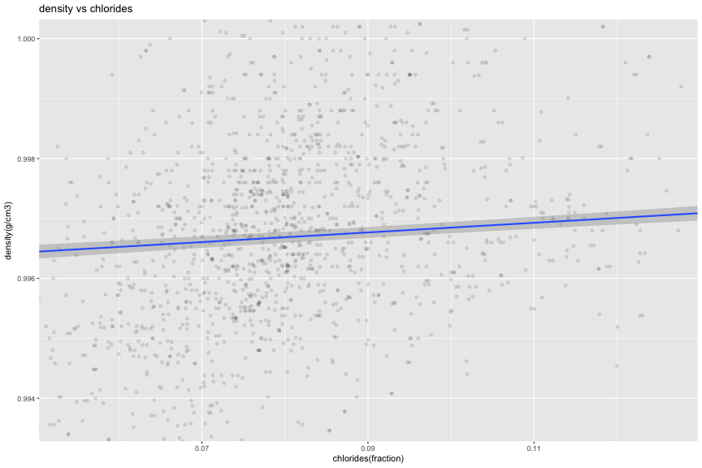

3.5 sulphates v.s. chlorides As we all know that the sulphates and chlorides are metablites of saccharomycetes in the furmentation, the amount of those two chemicals should be positively correlated. Such guess is also verified in the following plot.

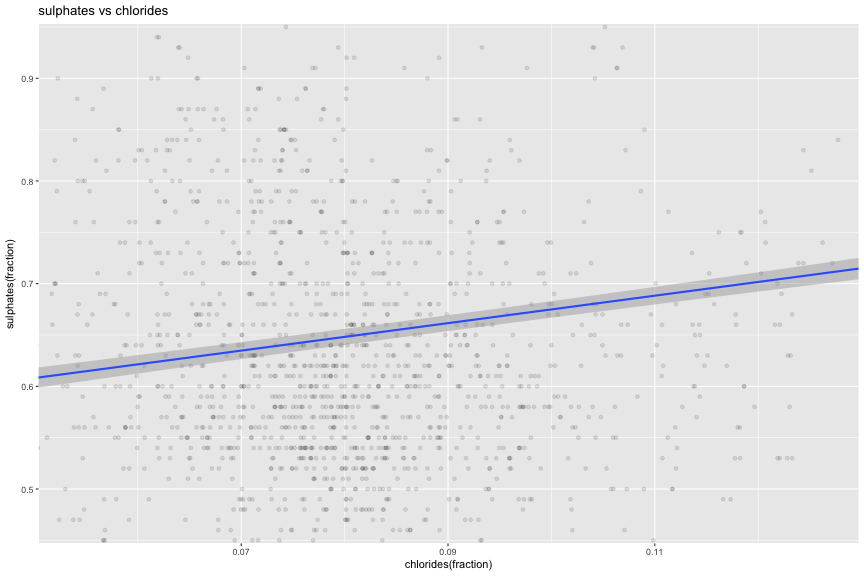

3.6 Quality v.s. alcohol The most important relation should be quality v.s. alcohol, as alcohol is the essential compoment of wine, and is the fundemental factor effecting quality.

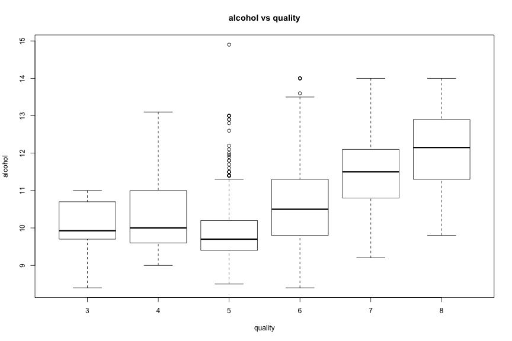

# Multivariate Plots Section

> **Tip**: Now it's time to put everything together. Based on what you found in the bivariate plots section, create a few multivariate plots to investigate more complex interactions between variables. Make sure that the plots that you create here are justified by the plots you explored in the previous section. If you plan on creating any mathematical models, this is the section where you will do that.

# Multivariate Analysis

In some cases, the two attributes contribute to the wine quality together, not simply following the linear overlapping rule of those two variables. Here I would like to test the contribution of several pairs of attributes to the wine quality.

4.1 Chlorides and Sulphates – quality

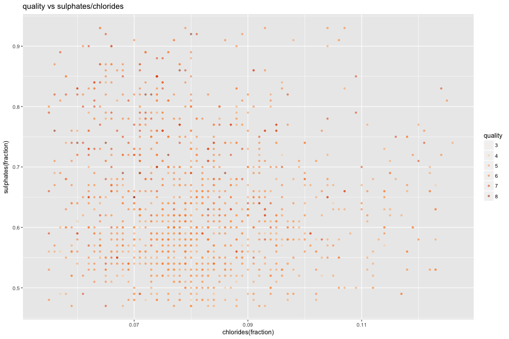

From this plot, we may notice that in the medium amount area of both chlorides and sulphates, there are more bottles of red wine rated as 6 or 7. Also, mainly residing in the upper left section, with chlorides in (0.07, 0.09) and sulphates in (0.65, 0.85), there are red wine scored 8.

4.2 Fixed acidity and volatile acidity – quality We all know that acid affects the flavor of red wine, and consequently the quality. Thus, here we will look at those two factors interacting with quality:

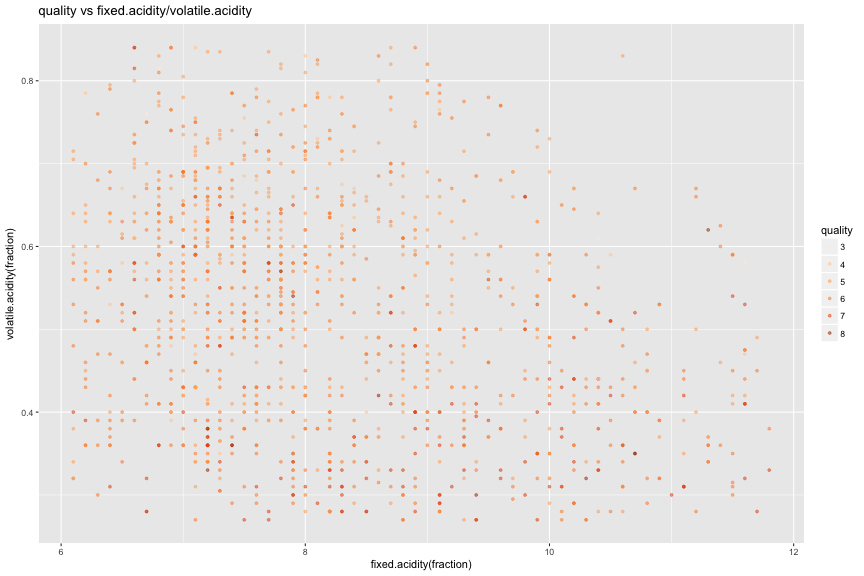

Apparently, the high quality wine (socred 7 or 8) is mialy located in the bottom of the plot, or to say, with more fixed.acidity than volatile.acidity. The ideal range of fixed.acidity is in (7.5, 11).

4.3 Free sulfur dioxide and total sulfur dioxide – quality

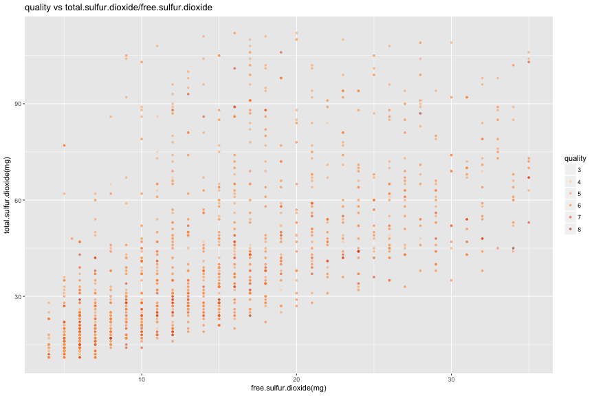

One interesting phenomenon is that the amount of total sulfur dioxide and free sulfur dioxide achieve high quality wine, scored with 6, 7 or even 8, along the line y = 1.5 x, especially in the range of (2, 30) for free sulfur dioxide.

4.4 Alcohol and PH – quality

In secition 4.2, we understand that an appropriate combnation of fixed acidity and volative acidity achieve better quality. Thus, we are wondering what the ideal combination will be if take the main factor – alcohol, into account. As acids affect PH value, here we will look at the alcohol level and PH level.

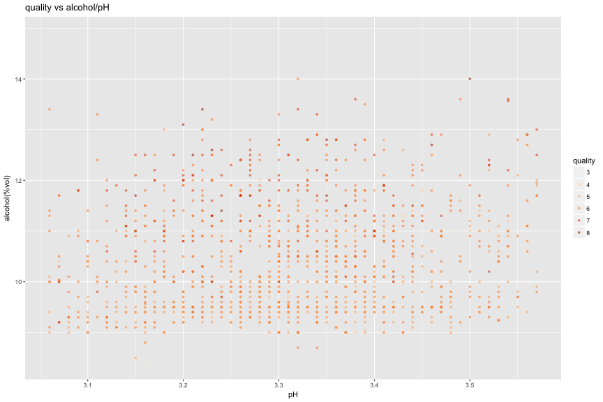

Clearly, wine which is too sour (pH less than 3.1) and wine which is not sour enough (pH>3.4) are much less popular than the wine with pH value within. At such pH values, the wine containing alcohol between 11 and 13 are highestly scored.

### Talk about some of the relationships you observed in this part of the \

investigation. Were there features that strengthened each other in terms of \ looking at your feature(s) of interest?

### Were there any interesting or surprising interactions between features?

Yes, it seems that the total sulfur dioxide and the free sulfur dioxide are highly correlated, and produce the high score wine when they are approximately in linear relation. Also from the previous analysis, we may notice that the experts have preference of relatively higher sulphates/lower chlorides, higer fixed acidity/lower volitile acidity, and pH around 3.3/alcohol around 12.

### OPTIONAL: Did you create any models with your dataset? Discuss the \

strengths and limitations of your model.

# Final Plots and Summary

> **Tip**: You've done a lot of exploration and have built up an understanding of the structure of and relationships between the variables in your dataset. Here, you will select three plots from all of your previous exploration to present here as a summary of some of your most interesting findings. Make sure that you have refined your selected plots for good titling, axis labels (with units), and good aesthetic choices (e.g. color, transparency). After each plot, make sure you justify why you chose each plot by describing what it shows.

### Plot One

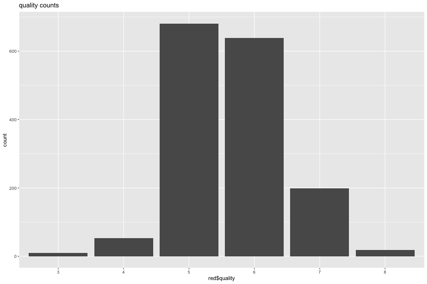

### Description One

The distribution of the quality is close to normal distribution – looking closely at the wine, we may notice that the wine in quality 5 and quality 6 are in the middle of the wine quality range [3, 8], and thus contain most of the wine counts. quality 4 and 7 own much less wine counts, while quality 3 and 8 own the least wine counts. Such distribution obeys the normal distribution, obviously.

### Plot Two

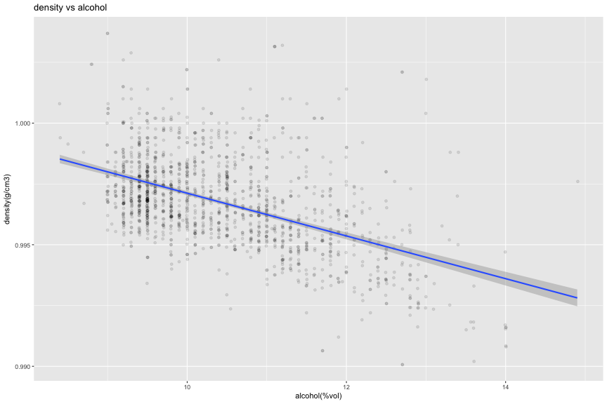

### Description Two

In this plot, I plotted the density over alcohol content. As we can see, wine containing 10% alcohol tends to have about 0.997 g per cm3, while the wine with 12% alcohol only have about 0.9955 g per cm3. such relationship is further demonstrated by the straight line regressed from the data to show us the trend that the density of wine descreases when alcohol content goes up.

### Plot Three

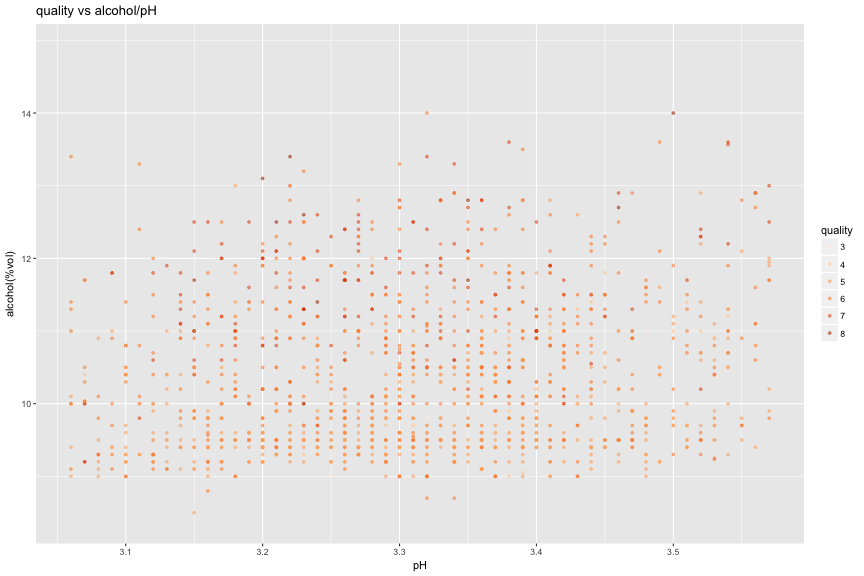

### Description Three

# Reflection

> **Tip**: Here's the final step! Reflect on the exploration you performed and the insights you found. What were some of the struggles that you went through? What went well? What was surprising? Make sure you include an insight into future work that could be done with the dataset.

[output not shown]